# text mining and sentiment analysis in Game of Thrones

Tjebbe A. Veltman

2022-12-02

```r
library(tidyverse)
library(here)
# For text mining:
library(pdftools)
```

```r
library(tidytext)
library(textdata)
library(ggwordcloud)
# Note - Before lab:
# Attach tidytext and textdata packages
# Run: get_sentiments(lexicon = "nrc")
# Should be prompted to install lexicon - choose yes!
# Run: get_sentiments(lexicon = "afinn")
# Should be prompted to install lexicon - choose yes!
```

```r
#getting the data
GoT_path <- here("data","got.pdf")
GoT_text <- pdf_text(GoT_path)
```

```r
#finding page 9
GoT_p9 <- GoT_text[9]
GoT_p9
```

```
## [1] "one before, when I was half a boy. Everyone talks about snows forty foot deep, and how\nthe ice wind comes howling out of the north, but the real enemy is the cold. It steals up\non you quieter than Will, and at first you shiver and your teeth chatter and you stamp\nyour feet and dream of mu…
```

#wrangling - Split up pages into separate lines (separated by `\n`) using `stringr::str_split()` - Unnest into regular columns using `tidyr::unnest()` - Remove leading/trailing white space with `stringr::str_trim()

```r
#
GoT_df <- data.frame(GoT_text) %>%
  mutate(text_full = str_split(GoT_text, pattern = '\\n')) %>%
  unnest(text_full) %>%
  mutate(text_full = str_trim(text_full))
```

### Get the tokens (individual words) in tidy format

Use `tidytext::unnest_tokens()` (which pulls from the `tokenizer`) package, to split columns into tokens. We are interested in *words*, so that’s the token we’ll use:

```r
GoT_tokens <- GoT_df %>%
  unnest_tokens(word, text_full)
```

#count the words

```r
GoT_wc <- GoT_tokens %>%
  count(word) %>%
  arrange(-n)
GoT_wc
```

```
## # A tibble: 11,826 × 2
##    word      n
##    <chr> <int>
##  1 the   17988
##  2 and    8997
##  3 to     6640
##  4 a      6461
##  5 of     6200
##  6 he     5166
##  7 his    5161
##  8 was    3904
##  9 her    3659
## 10 you    3267
## # … with 11,816 more rows
```

```r
View(stop_words)
```

OK…so we notice that a whole bunch of things show up frequently that we might not be interested in (“a”, “the”, “and”, etc.). These are called *stop words*. Let’s remove them.

### Remove stop words:

See `?stop_words` and `View(stop_words)`to look at documentation for stop words lexicons.

We will *remove* stop words using `tidyr::anti_join()`:

```r
GoT_stop <- GoT_tokens %>%
  anti_join(stop_words) %>%
  select(-GoT_text)
```

Now check the counts again:

```r
GoT_swc <- GoT_stop %>%
  count(word) %>%
  arrange(-n)
```

What if we want to get rid of all the numbers (non-text) in `GoT_stop`?

```r
# This code will filter out numbers by asking:
# If you convert to as.numeric, is it NA (meaning those words)?
# If it IS NA (is.na), then keep it (so all words are kept)
# Anything that is converted to a number is removed
GoT_no_numeric <- GoT_stop %>%
filter(is.na(as.numeric(word)))
length(unique(GoT_no_numeric$word))
```

```
## [1] 11209
```

```r
# We probably don't want to include them all in a word cloud. Let's filter to only include the top 100 most frequent?
GoT_top100 <- GoT_no_numeric %>%
  count(word) %>%
  arrange(-n) %>%
  head(100)
```

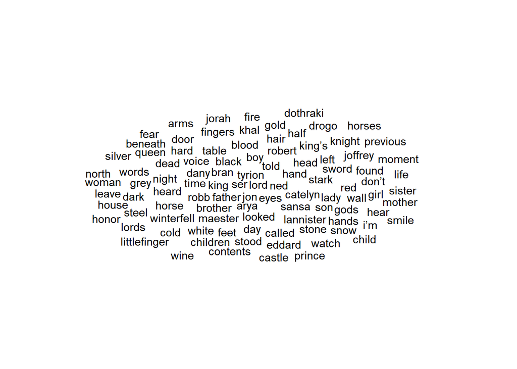

```r
#making a word cloud
GoT_cloud <- ggplot(data = GoT_top100, aes(label = word)) +
  geom_text_wordcloud() +
  theme_minimal()

GoT_cloud
```

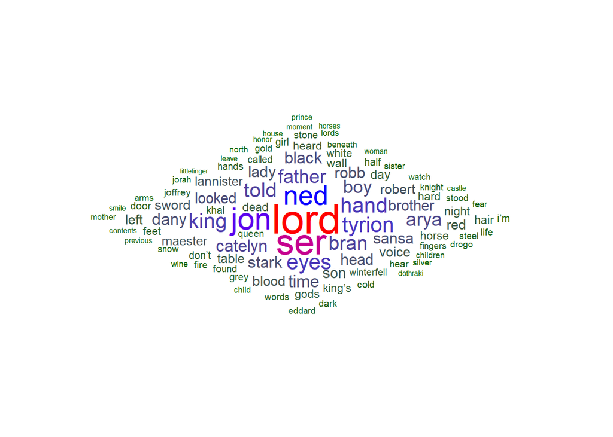

```r
#customized cloud
ggplot(data = GoT_top100, aes(label = word, size = n)) +
  geom_text_wordcloud_area(aes(color = n), shape = "diamond") +
  scale_size_area(max_size = 12) +
  scale_color_gradientn(colors = c("darkgreen","blue","red")) +
  theme_minimal()
```

- AFINN from Finn Årup Nielsen, - bing from Bing Liu and collaborators, and - nrc from Saif Mohammad and Peter Turney

All three of these lexicons are based on unigrams, i.e., single words. These lexicons contain many English words and the words are assigned scores for positive/negative sentiment, and also possibly emotions like joy, anger, sadness, and so forth. The AFINN lexicon assigns words with a score that runs between -5 and 5, with negative scores indicating negative sentiment and positive scores indicating positive sentiment. The bing lexicon categorizes words in a binary fashion into positive and neYgative categories. The nrc lexicon categorizes words in a binary fashion (“yes”/“no”) into categories of positive, negative, anger, anticipation, disgust, fear, joy, sadness, surprise, and trust. All of this information is tabulated in the sentiments dataset, and tidytext provides a function get_sentiments() to get specific sentiment lexicons without the columns that are not used in that lexicon.”

```r
#trying out the different sets
get_sentiments(lexicon = "afinn")
```

```
## # A tibble: 2,477 × 2
##    word       value
##    <chr>      <dbl>
##  1 abandon       -2
##  2 abandoned     -2
##  3 abandons      -2
##  4 abducted      -2
##  5 abduction     -2
##  6 abductions    -2
##  7 abhor         -3
##  8 abhorred      -3
##  9 abhorrent     -3
## 10 abhors        -3
## # … with 2,467 more rows
```

```r
# Note: may be prompted to download (yes)
```

```r
#bing
get_sentiments(lexicon = "bing")
```

```
## # A tibble: 6,786 × 2
##    word        sentiment
##    <chr>       <chr>
##  1 2-faces     negative
##  2 abnormal    negative
##  3 abolish     negative
##  4 abominable  negative
##  5 abominably  negative
##  6 abominate   negative
##  7 abomination negative
##  8 abort       negative
##  9 aborted     negative
## 10 aborts      negative
## # … with 6,776 more rows
```

```r
#nrc
get_sentiments(lexicon = "nrc")
```

```
## # A tibble: 13,872 × 2
##    word        sentiment
##    <chr>       <chr>
##  1 abacus      trust
##  2 abandon     fear
##  3 abandon     negative
##  4 abandon     sadness
##  5 abandoned   anger
##  6 abandoned   fear
##  7 abandoned   negative
##  8 abandoned   sadness
##  9 abandonment anger
## 10 abandonment fear
## # … with 13,862 more rows
```

```r
GoT_stop
```

```
## # A tibble: 118,281 × 1
##    word
##    <chr>
##  1 game
##  2 thrones
##  3 book
##  4 song
##  5 ice
##  6 fire
##  7 george
##  8 r.r
##  9 martin
## 10 contents
## # … with 118,271 more rows
```

Let’s do sentiment analysis on the GoT text data using afinn, and nrc

```r
GoT_afinn <- GoT_stop %>%
  inner_join(get_sentiments("afinn"))
GoT_afinn
```

```
## # A tibble: 13,058 × 2
##    word  value
##    <chr> <dbl>
##  1 fire     -2
##  2 dead     -3
##  3 dead     -3
##  4 smile     2
##  5 dead     -3
##  6 dead     -3
##  7 dead     -3
##  8 dead     -3
##  9 dead     -3
## 10 drag     -1
## # … with 13,048 more rows
```

### Sentiment analysis with afinn:

```r
GoT_afinn <- GoT_stop %>%
  inner_join(get_sentiments("afinn"))
```

Let’s find some counts (by sentiment ranking):

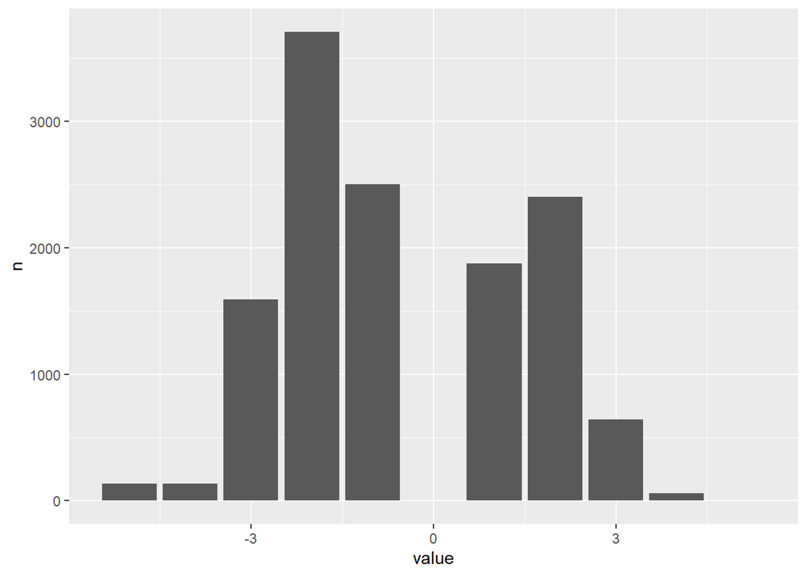

```r
GoT_afinn_hist <- GoT_afinn %>%
  count(value)

# Plot them:
ggplot(data = GoT_afinn_hist, aes(x = value, y = n)) +
  geom_col()
```

```r
GoT_afinn_minus_5 <- GoT_afinn %>%
  filter(value ==-5)
```

Visualization of the top 6 most used bad words

```r
unique(GoT_afinn_minus_5$word)
```

```
## [1] "bastard"  "bitch"    "bastards" "slut"     "cunt"     "cock"
```

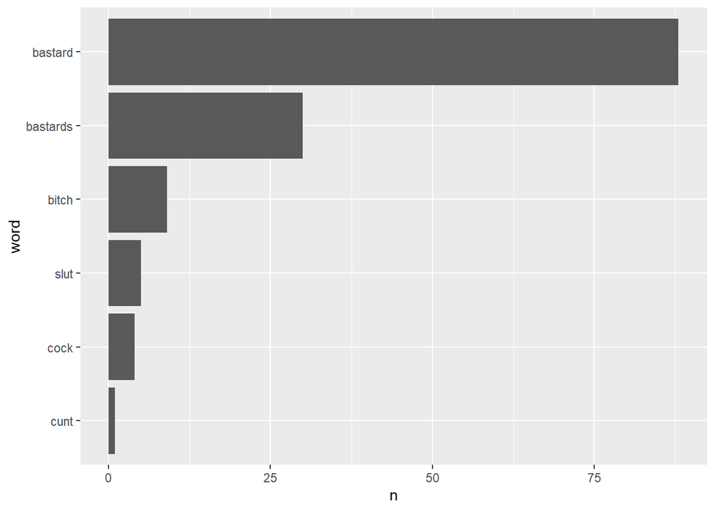

```r
# Count & plot them
GoT_afinn_minus_5_n <- GoT_afinn_minus_5 %>%
  count(word, sort = TRUE) %>%
  mutate(word = fct_reorder(factor(word), n))


ggplot(data = GoT_afinn_minus_5_n, aes(x = word, y = n)) +
  geom_col() +
  coord_flip()
```

```r
GoT_summary <- GoT_afinn %>%
  summarize(
    mean_score = mean(value),
    median_score = median(value)
  )
```

```r
GoT_nrc <- GoT_stop %>%
  inner_join(get_sentiments("nrc"))
GoT_exclude <- GoT_stop %>%
  anti_join(get_sentiments("nrc"))
# View(GoT_exclude)

# Count to find the most excluded:
GoT_exclude_n <- GoT_exclude %>%
  count(word, sort = TRUE)

head(GoT_exclude_n)
```

```
## # A tibble: 6 × 2
##   word       n
##   <chr>  <int>
## 1 ser     1023
## 2 jon      787
## 3 ned      743
## 4 tyrion   591
## 5 eyes     567
## 6 hand     567
```

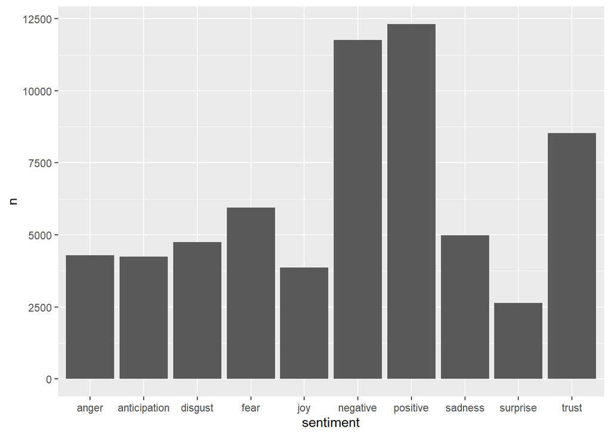

```r
GoT_nrc_n <- GoT_nrc %>%
  count(sentiment, sort = TRUE)

# And plot them:

ggplot(data = GoT_nrc_n, aes(x = sentiment, y = n)) +
  geom_col()
```

```r
GoT_nrc_n5 <- GoT_nrc %>%
  count(word,sentiment, sort = TRUE) %>%
  group_by(sentiment) %>%
  top_n(5) %>%
  ungroup()
```

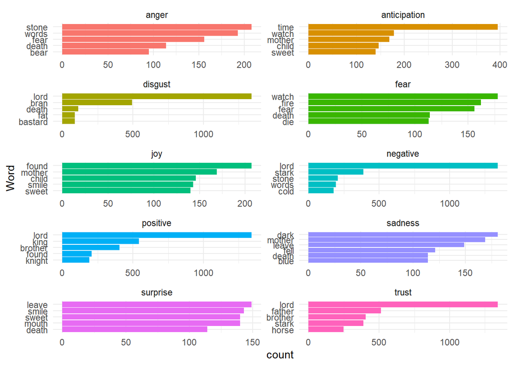

```r
GoT_nrc_gg <- ggplot(data = GoT_nrc_n5, aes(x = reorder(word,n), y = n, fill = sentiment)) +
  geom_col(show.legend = FALSE) +
  facet_wrap(~sentiment, ncol = 2, scales = "free") +
  coord_flip() +
  theme_minimal() +
  labs(x = "Word", y = "count")

# Show it
GoT_nrc_gg
```

```r
# Save it
ggsave(plot = GoT_nrc_gg,
       here("figures","GoT_nrc_sentiment.png"),
       height = 8,
       width = 5)
```

```r
conf <- get_sentiments(lexicon = "nrc") %>%
  filter(word == "confidence")

conf
```

```
## # A tibble: 4 × 2
##   word       sentiment
##   <chr>      <chr>
## 1 confidence fear
## 2 confidence joy
## 3 confidence positive
## 4 confidence trust
```